# Chapter12 様々なグラフを作る

### 12.4.3 値に応じてマーカーの大きさを設定する

- マーカーの大きさで値の大きさを表現することが可能
  - **`scatter()`** の引数で **`s="データ"`** として渡す

#### マーカーの大きさを設定する例

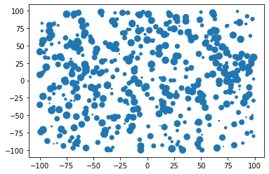

```python
import numpy as np
import matplotlib.pyplot as plt
%matplotlib inline

np.random.seed(0)
## x軸、y軸データを作成
x = np.random.choice(np.arange(-100, 100), 500)
y = np.random.choice(np.arange(-100, 100), 500)
## もう1種類のデータを作成
z = np.random.choice(np.arange(100), 500)

# 散布図を作成
# zのデータを用いてマーカーの大きさを指定
plt.scatter(x, y, s=z)

plt.show()
```

### 12.4.4 値に応じてマーカーの濃さを設定する

- マーカーの色の濃さで値の大きさを表現することも可能
  - **`scatter()`** の引数で **`c="濃さに対応するデータ"`** として渡す
  - **`cmap="色系統"`** を指定することで、色の指定も可能
    - 色系統指定子の例
      - "Reds":赤
      - "Blues":青
      - "Greens":緑
      - "Purples":紫

#### マーカーの濃さ設定の例

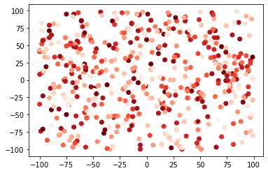

```python
import numpy as np
import matplotlib.pyplot as plt
%matplotlib inline

np.random.seed(0)
## x軸、y軸データを作成
x = np.random.choice(np.arange(-100, 100), 500)
y = np.random.choice(np.arange(-100, 100), 500)
## もう1種類のデータを作成
z = np.random.choice(np.arange(100), 500)

# 散布図を作成
# zのデータを用いてマーカーの濃さを指定
plt.scatter(x, y, c=z, cmap="Reds")

plt.show()
```

### 12.4.5 カラーバーを表示する

- マーカーの濃さと値の大きさの目安としてカラーバーを表示させることが可能
  - **`matplotlib.pyplot.colorbar()`** で表示

#### カラーバー表示の例

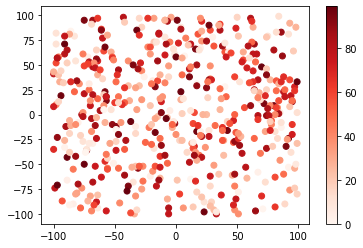

```python
import numpy as np
import matplotlib.pyplot as plt
%matplotlib inline

np.random.seed(0)
## x軸、y軸データを作成
x = np.random.choice(np.arange(-100, 100), 500)
y = np.random.choice(np.arange(-100, 100), 500)
## もう1種類のデータを作成
z = np.random.choice(np.arange(100), 500)

# 散布図を作成
# zのデータを用いてマーカーの濃さを指定
plt.scatter(x, y, c=z, cmap="Reds")

## カラーバーの表示
plt.colorbar()

plt.show()
```

## 12.5 円グラフ

### 12.5.1 円グラフを作成する

- 円グラフの作成
  - **`matplotlib.pyplot.pie()`**
- **`matplotlib.pyplot.axis("equal")`** を指定することで真円のグラフとなる
  - 指定しないと楕円のグラフとなる

#### 円グラフの作成例

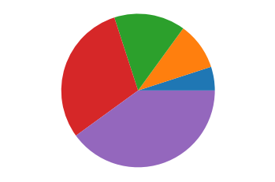

```python
import numpy as np
import matplotlib.pyplot as plt
%matplotlib inline

data = [5, 10, 15, 30, 40]

# dataを円グラフとして可視化
plt.pie(data)

# 円グラフが真円になるように指定
plt.axis("equal")

plt.show()
```

### 12.5.2 円グラフにラベルを設定する

- 円グラフの各データにラベルの設定が可能
  - **`pie()`** の引数で **`labels="ラベル用のリスト"`** として渡す

#### ラベル設定の例

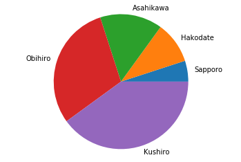

```python
import numpy as np
import matplotlib.pyplot as plt
%matplotlib inline

data = [5, 10, 15, 30, 40]
cities = ["Sapporo", "Hakodate", "Asahikawa", "Obihiro", "Kushiro"]

# dataを円グラフとして可視化
# グラフラベルも設定
plt.pie(data, labels=cities)

# 円グラフが真円になるように指定
plt.axis("equal")

plt.show()
```

### 12.5.3 特定の要素を目立たせる

- グラフ中の特定の要素だけを切り離して強調させることが可能
  - **`pie()`** の引数で **`explode="目立たせ度合いのリスト"`** として渡す
    - 目立たせ度合いは0から1の値で指定する

#### 特定の要素を目立たせる例

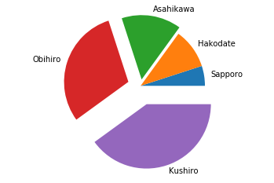

```python
import numpy as np
import matplotlib.pyplot as plt
%matplotlib inline

data = [5, 10, 15, 30, 40]
cities = ["Sapporo", "Hakodate", "Asahikawa", "Obihiro", "Kushiro"]
exp = [0, 0, 0.1, 0.2, 0.3]

# dataを円グラフとして可視化
# グラフラベルも設定
# explode指定で要素を目立たせる
plt.pie(data, labels=cities, explode=exp)

# 円グラフが真円になるように指定
plt.axis("equal")

plt.show()
```

## 12.6 3Dグラフ

### 12.6.1 3D Axesを作成する

- 3Dグラフを描画する
  - 3D描画機能を持ったサブプロットを作成する
  - **`matplotlib(.pyplot).figure().add_subplot(1,1,1,projection="3d")`**
    - **`add_subplot()`** の引数に **`projection="3d"`** と指定する
  - **mpl_toolkits.mplot3d** の **Axes3D** をimportする必要がある
  - 3Dの曲面を描画（**`plot_surface()`**）する場合、各軸のデータは2次元配列で用意する
    - **`numpy.meshgrid()`** 関数を用いるとX軸・Y軸の格子状のデータを作成しやすい

#### 3Dグラフ描画の例

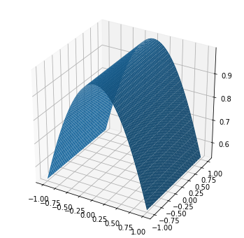

```python
import numpy as np
import matplotlib.pyplot as plt
# 3D描画を行うために必要なライブラリ
from mpl_toolkits.mplot3d import Axes3D
%matplotlib inline

# X軸データ
x = np.linspace(-1, 1, 50)
# Y軸データ
y = np.linspace(-1, 1, 50)
# X軸・Y軸データを組み合わせた格子状のデータを作成
X, Y = np.meshgrid(x, y)
# Z軸データ
Z = np.cos(X)

# Figureオブジェクトを作成
fig = plt.figure(figsize=(6,6))
# 3D描画できるサブプロットaxを作成
ax = fig.add_subplot(1,1,1,projection="3d")

# 曲面をプロット
ax.plot_surface(X, Y, Z)
plt.show()
```

### 12.6.2 曲面を作成する

- サブプロット **ax** に3次元のデータを利用して曲面を描画する
  - **`ax.plot_surface(X, Y, Z)`**
  - X,Y,Zデータは2次元配列とする

#### 曲面作成の例

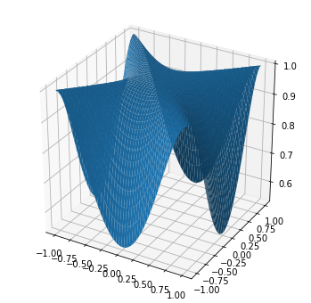

```python
import numpy as np
import matplotlib.pyplot as plt
# 3D描画を行うために必要なライブラリ
from mpl_toolkits.mplot3d import Axes3D
%matplotlib inline

# X軸データ
x = np.linspace(-1, 1, 50)
# Y軸データ
y = np.linspace(-1, 1, 50)
# X軸・Y軸データを組み合わせた格子状のデータを作成
X, Y = np.meshgrid(x, y)
# Z軸データ
Z = np.cos(X**2 - Y**2)

# Figureオブジェクトを作成
fig = plt.figure(figsize=(6,6))
# 3D描画できるサブプロットaxを作成
ax = fig.add_subplot(1,1,1,projection="3d")

# 曲面をプロット
ax.plot_surface(X, Y, Z)
plt.show()
```

### 12.6.3 3Dヒストグラムを作成する

- サブプロット **ax** に3次元でヒストグラムまたは棒グラフを作成する
  - **`ax.bar3d(xpos, ypos, zpos, dx, dy, dz)`**
    - xpos, ypos, zpos：各軸の座標
    - dx, dy, dz：各軸方向の変化量（グラフの高さ）

#### 3Dヒストグラムの例

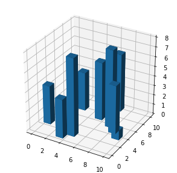

```python
import matplotlib.pyplot as plt
import numpy as np
# 3D描画を行うために必要なライブラリ
from mpl_toolkits.mplot3d import Axes3D
import random
%matplotlib inline

np.random.seed(0)
random.seed(0)
# X,Yの座標用データ
l = set(np.arange(0,10))

# Figureオブジェクトを作成
fig = plt.figure(figsize=(5, 5))
# サブプロットaxを作成
ax = fig.add_subplot(1, 1, 1, projection="3d")
# x, y, zの座標データ
xpos = random.sample(l, 10)
ypos = random.sample(l, 10)
zpos = np.zeros(10)
# x, y, zの増加量
dx = np.ones(10)
dy = np.ones(10)
dz = np.random.choice(np.arange(1,10), 10)

# 3次元のヒストグラムを作成してください
ax.bar3d(xpos, ypos, zpos, dx, dy, dz)

plt.show()
```

### 12.6.4 3D散布図を作成する

- サブプロット **axに** 3種類のデータを用いた3次元散布図の作成
  - **`ax.scatter3d(X, Y, Z)`**
- 多次元データを1次元に変換する場合、 **`numpy.ravel()`** が利用できる

#### 3次元散布図の例

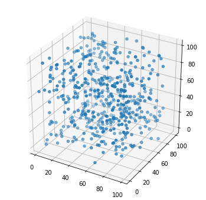

```python
import numpy as np
import matplotlib.pyplot as plt
# 3D描画を行うために必要なライブラリ
from mpl_toolkits.mplot3d import Axes3D
np.random.seed(0)
%matplotlib inline

# X, Y, Z軸のデータの作成
X = np.random.choice(np.arange(1,100), 500)
Y = np.random.choice(np.arange(1,100), 500)
Z = np.random.choice(np.arange(1,100), 500)

# Figureオブジェクトを作成
fig = plt.figure(figsize=(6, 6))
# サブプロットaxを作成
ax  = fig.add_subplot(1, 1, 1, projection="3d")
# 3D散布図を作成
ax.scatter3D(X, Y, Z)

plt.show()
```

### 12.6.5 3Dグラフにカラーマップを適用する

- 3Dグラフの第3引数（Z軸方向のデータ）についてカラーマップを適用できる
  - **matplotlib** から **cm** をimport
  - プロット時に引数として **`cmap=cm.coolwarm`** を渡す
  - プロットに対して **`colorbar()`** 関数を利用することでカラーバーの表示もできる

#### 3Dグラフにカラーマップを適用した例

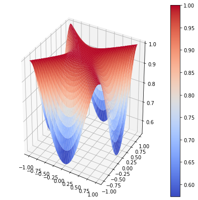

```python
import numpy as np
import matplotlib.pyplot as plt
# 3D描画を行うために必要なライブラリ
from mpl_toolkits.mplot3d import Axes3D
# カラーマップを表示するためのライブラリ
from matplotlib import cm
%matplotlib inline

# X軸データ
x = np.linspace(-1, 1, 50)
# Y軸データ
y = np.linspace(-1, 1, 50)
# X軸・Y軸データを組み合わせた格子状のデータを作成
X, Y = np.meshgrid(x, y)
# Z軸データ
Z = np.cos(X**2 - Y**2)

# Figureオブジェクトを作成
fig = plt.figure(figsize=(7,7))
# 3D描画できるサブプロットaxを作成
ax = fig.add_subplot(1,1,1,projection="3d")

# 曲面をプロット
# Z軸データについてカラーマップを適用
surf = ax.plot_surface(X, Y, Z, cmap=cm.coolwarm)

# カラーバーの表示も可能
fig.colorbar(surf)

plt.show()
```

# ほげ要望

第１２章の添削問題をやってくれたら工藤が喜びます

# エクストラほげ問題

機械学習を学ぶ際に数学の知識がよく出てきますね。  
データマイニングと呼ばれる技法があります。その技法の具体的な技法を三つ以上調べてまとめなさい。  
数式で説明すると工藤が喜びます。